# Multilayer Perceptron

#### Karol Krupa, Paweł Flis

Low-level implementation of neural network in Python.

## Learning process visualization

In order to track the learning process iteration by iteration we need to pass an integer value **render_step** into train function. In this case user will be able to see weigths along with the gradients after every **render_step-th** batch. User can proceed to next iteration by pressing **Enter**

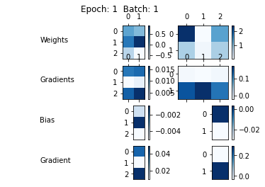

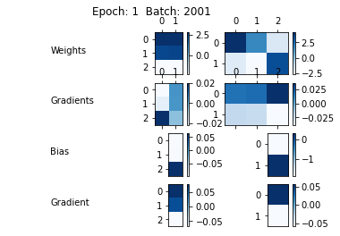

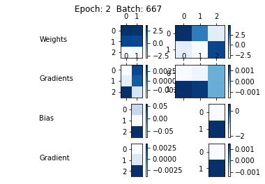

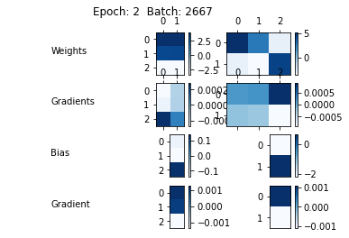

```python
from Perceptron import *
import numpy as np
import matplotlib.pyplot as plt


np.random.seed(1)

mlp = Perceptron(problem_type=Perceptron.ProblemType.Classification,
                     hidden_layers=[3],
                     activation=sigmoid,
                     dActivation=dSigmoid,
                     final=sigmoid,
                     dFinal=dSigmoid,
                     batch_size=3,
                     learning_rate=0.1,
                     momentum=0.1,
                     epochs=2,
                     bias=True)
mlp.load("data\data.simple.train.10000.csv")
_ = mlp.train(render_step=2000)
```

## Compliance tests

### Classification

First test was conducted on data.simple dataset.

```python
from Perceptron import *
import numpy as np
import matplotlib.pyplot as plt

np.random.seed(1)
mlp = Perceptron(problem_type=Perceptron.ProblemType.Classification,
                     hidden_layers=[3],
                     activation=sigmoid,
                     dActivation=dSigmoid,
                     final=sigmoid,
                     dFinal=dSigmoid,
                     batch_size=3,
                     learning_rate=0.1,
                     momentum=0.1,
                     epochs=1,
                     bias=False)
mlp.load("data\data.simple.train.10000.csv")
_ = mlp.train()
mlp.test_classification("data\data.simple.test.10000.csv")
```

```
Success ratio: 0.9927
```

The model trained during just one epoch turns out to achieve extremely good results. Thats is caused by the fact, that the data set is indeed simple and almost linearly separable.

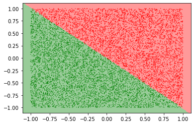

```python
draw_classification(mlp, "data\data.simple.test.10000.csv")
```

Next test was conducted on **data.three_gauss** dataset. **SM_CE** flag set as **True** means that provided final activation function and loss function will be ignored and **Softmax** activation with **Cross entropy** loss will be used instead. This combination is used due to simplified derivative of this composite $$\frac{\partial E}{\partial y_j}=predicted_j-actual_j$$

```python
mlp = Perceptron(problem_type=Perceptron.ProblemType.Classification,
                 hidden_layers=[3],
                 activation=sigmoid,
                 dActivation=dSigmoid,
                 SM_CE=True,
                 batch_size=3,
                 learning_rate=0.1,
                 momentum=0.1,
                 epochs=10,
                 bias=True)
mlp.load("data\data.three_gauss.train.10000.csv")
_ = mlp.train()
mlp.test_classification("data\data.three_gauss.test.10000.csv")
```

```
Success ratio: 0.9287
```

In this case model achieves satisfactory results. As we can see on the image below all three sets intersect with each other in proximity of point (0,0).

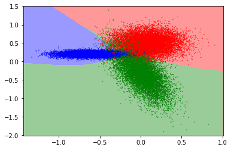

```python
draw_classification(mlp, "data\data.three_gauss.test.10000.csv")
```

## Regression

We tested the regression funcinality with custom generated dataset from function $y=x^2$.

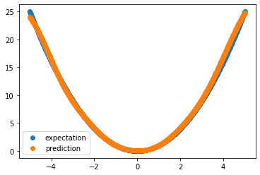

```python
mlp = Perceptron(problem_type=Perceptron.ProblemType.Regression,
                 hidden_layers=[10],
                 activation=sigmoid,
                 dActivation=dSigmoid,
                 batch_size=3,
                 learning_rate=0.01,
                 momentum=0.1,
                 epochs=30,
                 bias=True)

mlp.load("data\quadratic1_train.csv")
_ = mlp.train()
draw_regression2d(mlp, x=np.linspace(-5, 5, 1000), func=lambda x: x**2)
```

The model converges and models the function accurately. By trial we deduced that it is important to use very low learning_rate value and low momentum in case of regression problem.

Three dimensional function $z=x^2+xy+5x-1$

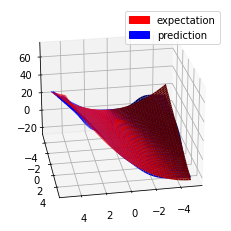

```python
mlp = Perceptron(problem_type=Perceptron.ProblemType.Regression,
                 hidden_layers=[12],
                 activation=sigmoid,
                 dActivation=dSigmoid,
                 batch_size=3,
                 learning_rate=0.01,
                 momentum=0.1,
                 epochs=30,
                 bias=True)

mlp.load("data\\3d_train.csv")
_ = mlp.train()
draw_regression3d(mlp,
                  x=np.linspace(-5, 5, 50),
                  y=np.linspace(-5, 5, 50),
                  func=lambda x, y:  x**2+x*y+5*x-1)
```

## Activation function analysis

We will test different activation functions in classification of three_gauss set of data. Rest of the parameters will be the same.

```
Success ratio: 0.9240333333333334
```

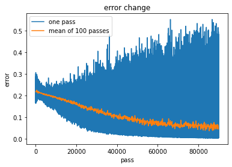

```
Last mean error: 0.044687488032672314
```

```python
mlp = Perceptron(problem_type=Perceptron.ProblemType.Classification,
                 hidden_layers=[3],
                 activation=sigmoid,
                 dActivation=dSigmoid,
                 final=sigmoid,
                 dFinal=dSigmoid,
                 batch_size=3,
                 learning_rate=0.01,
                 momentum=0.1,
                 epochs=3,
                 bias=True)
mlp.load("data\data.three_gauss.train.10000.csv")
losses = mlp.train()
mlp.test_classification("data\data.three_gauss.test.10000.csv")
plot_errors(losses)
```

```
Success ratio: 0.9302666666666667
```

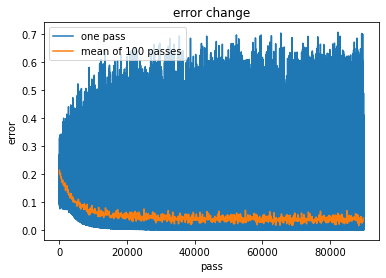

```
Last mean error: 0.042449283796684514
```

```python
mlp = Perceptron(problem_type=Perceptron.ProblemType.Classification,
                 hidden_layers=[3],
                 activation=tanh,
                 dActivation=dTanh,
                 final=sigmoid,
                 dFinal=dSigmoid,
                 batch_size=3,
                 learning_rate=0.01,
                 momentum=0.1,
                 epochs=3,
                 bias=True)
mlp.load("data\data.three_gauss.train.10000.csv")
losses = mlp.train()
mlp.test_classification("data\data.three_gauss.test.10000.csv")
plot_errors(losses)
```

Both previous cases were tested with Mean Squared Error loss function. We would see model would behave with Softmax + Cross Entropy coombination.

```
Success ratio: 0.9299
```

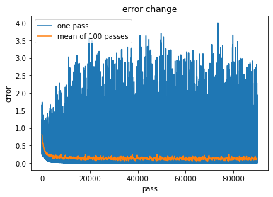

```
Last mean error: 0.14384401251262843
```

```python
mlp = Perceptron(problem_type=Perceptron.ProblemType.Classification,
                 hidden_layers=[3],
                 activation=tanh,
                 dActivation=dTanh,
                 SM_CE=True,
                 batch_size=3,
                 learning_rate=0.01,
                 momentum=0.1,
                 epochs=3,
                 bias=True)
mlp.load("data\data.three_gauss.train.10000.csv")
losses = mlp.train()
mlp.test_classification("data\data.three_gauss.test.10000.csv")
plot_errors(losses)
```

We will test different activation functions in regression of function $y=x^2-3x-5$. In regression problems output layer function is identity.

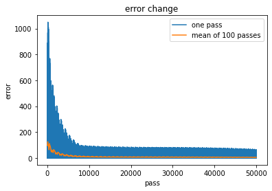

```
Last mean error: 4.112824001169653
```

```python
mlp = Perceptron(problem_type=Perceptron.ProblemType.Regression,
                 hidden_layers=[10],
                 activation=sigmoid,
                 dActivation=dSigmoid,
                 batch_size=3,
                 learning_rate=0.001,
                 momentum=0.1,
                 epochs=50,
                 bias=True)

mlp.load("data\quadratic2_train.csv")
losses = mlp.train()
plot_errors(losses)
```

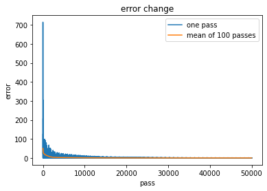

```
Last mean error: 0.06482873575846765
```

```python
mlp = Perceptron(problem_type=Perceptron.ProblemType.Regression,
                 hidden_layers=[10],
                 activation=ReLU,
                 dActivation=dReLU,
                 batch_size=3,
                 learning_rate=0.001,
                 momentum=0.1,
                 epochs=50,
                 bias=True)

mlp.load("data\quadratic2_train.csv")
losses = mlp.train()
plot_errors(losses)
```

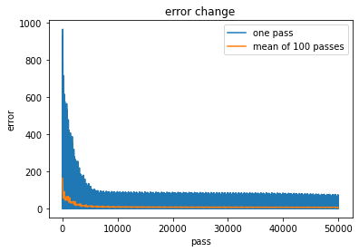

```
Last mean error: 3.331472981947718
```

```python
mlp = Perceptron(problem_type=Perceptron.ProblemType.Regression,
                 hidden_layers=[10],
                 activation=tanh,
                 dActivation=dTanh,
                 batch_size=3,
                 learning_rate=0.001,
                 momentum=0.1,
                 epochs=50,
                 bias=True)

mlp.load("data\quadratic2_train.csv")
losses = mlp.train()
plot_errors(losses)
```

ReLU seems to be the best activation function for that problem. Next one seems to be tanh function and the last one sigmoid function.

## Number of layers analysis

We will try various number of layers with 3 neurons each. Rest of parameters will remain the same. The dataset is **three_gauss.train**.

```
0 hidden layers, last mean error: 0.12289336173337333
```

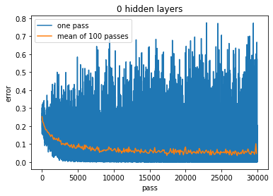

```
1 hidden layer, last mean error: 0.1439524190060294
```

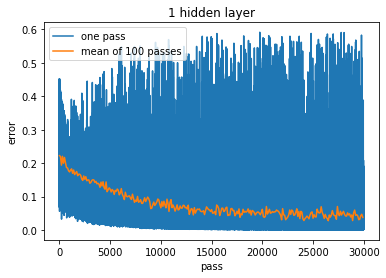

```
2 hidden layers, last mean error: 0.16450325638798324
```

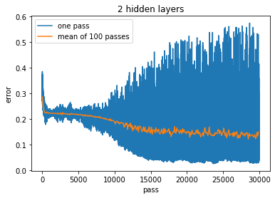

```
3 hidden layers, last mean error: 0.23970784220742222
```

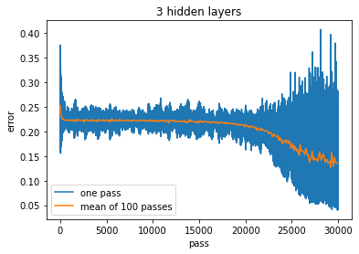

```
4 hidden layers, last mean error: 0.027053220808053332
```

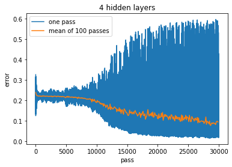

```
5 hidden layers, last mean error: 0.2044589025575204
```

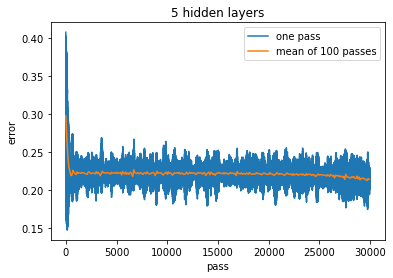

```python
layers = [[],
          [3],
          [3, 3],
          [3, 3, 3],
          [3, 3, 3, 3],
          [3, 3, 3, 3, 3]]
for ind, layer_type in enumerate(layers):
    mlp = Perceptron(problem_type=Perceptron.ProblemType.Classification,
                     hidden_layers=layer_type,
                     activation=sigmoid,
                     dActivation=dSigmoid,
                     final=sigmoid,
                     dFinal=dSigmoid,
                     batch_size=3,
                     learning_rate=0.05,
                     momentum=0.1,
                     epochs=1,
                     bias=True)
    mlp.load("data\data.three_gauss.train.10000.csv")
    losses = mlp.train()
    st = f'{ind} hidden layers' if ind != 1 else f'{ind} hidden layer'
    print(f'{st}, last mean error: {losses[-1]}')
    plot_errors_title(losses, st)
```

We will try various number of neurons (1, 2, 4, 8, ... 512) in one hidden layer.

```
1 hidden layer with 1 neuron, last mean error: 0.04996067180336707
```

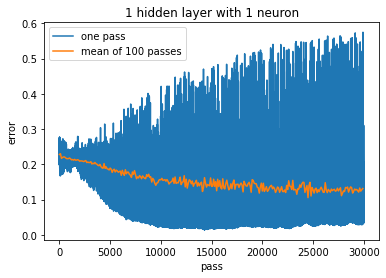

```
1 hidden layer with 2 neurons, last mean error: 0.003051048742627942
```

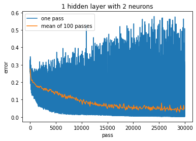

```
1 hidden layer with 4 neurons, last mean error: 0.0009091414908871812
```

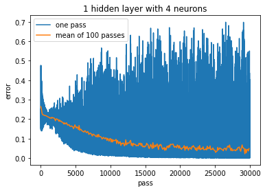

```
1 hidden layer with 8 neurons, last mean error: 0.0005045739899370072
```

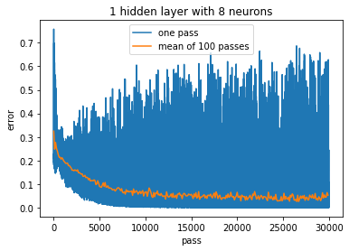

```
1 hidden layer with 16 neurons, last mean error: 0.01761506176017388
```

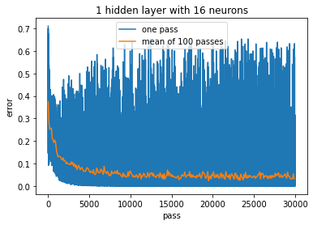

```
1 hidden layer with 32 neurons, last mean error: 7.180090893198804e-06
```

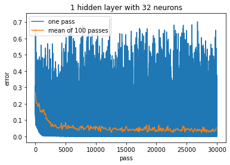

```
1 hidden layer with 64 neurons, last mean error: 0.00018747137585693922
```

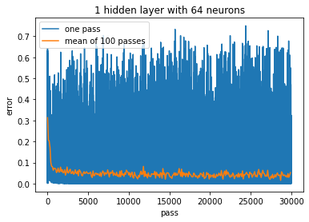

```
1 hidden layer with 128 neurons, last mean error: 0.000719423857488004
```

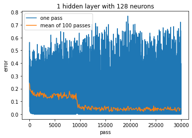

```
1 hidden layer with 256 neurons, last mean error: 0.00016207274769956066
```

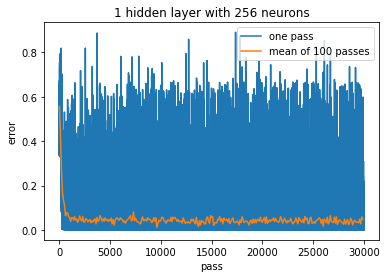

```
1 hidden layer with 512 neurons, last mean error: 0.0858759345623879
```

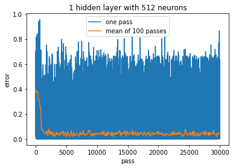

```python
layers = [[1],
          [2],
          [4],
          [8],
          [16],
          [32],
          [64],
          [128],
          [256],
          [512]]

for ind, layer_type in enumerate(layers):
    mlp = Perceptron(problem_type=Perceptron.ProblemType.Classification,
                     hidden_layers=layer_type,
                     activation=sigmoid,
                     dActivation=dSigmoid,
                     final=sigmoid,
                     dFinal=dSigmoid,
                     batch_size=3,
                     learning_rate=0.05,
                     momentum=0.1,
                     epochs=1,
                     bias=True)
    mlp.load("data\data.three_gauss.train.10000.csv")
    losses = mlp.train()
    st = f'1 hidden layer with {2 ** ind} neurons' if ind != 0 else f'1 hidden layer with{2 ** ind} neuron'
    print(f'{st}, last mean error: {losses[-1]}')
    plot_errors_title(losses, st)
```

Introducing additional neurons in 3 layer model does not necessarily give better results. The results vary in different cases, although time needed to train the model is increasing.